# Aula Rmarkdown

Érika S

31/07/2019

# Introdução

Você pode usar os arquivos de RMarkdown para as seguintes funcionalidades:

- Salvar e executar código
- Gerar relatórios de alta qualidade que podem ser compartilhados

Normalmente o arquivo RMarkdown contém três tipos de conteúdo:

- Um (opcional) cabeçalho YAML cercado por —s
- Chunks de código R cercado por ``` s
- Texto simples

# Chunks

Você pode inserir rapidamente um chunk das seguintes formas:

- No teclado apertando **Ctrl + Alt + I** (OS X: **Cmd + Option + I**)
- No botão Insert + R na barra de ferramentas do editor
- Ou escrevendo os delimitadores do chunk `{r} and`.

## Opções

As saídas do chunk poder ser customizadas, os argumentos são colocados dentro de {} no cabeçalho do chunk. Abaixo estaremos mostrando 4 argumentos:

- `include = FALSE` não deixa que o código e o resultado apareçam no arquivo final. o RMarkdown ainda roda o código do chunk, mas não é mostrado no arquivo gerado.
- `echo = FALSE` não deixa o código ser mostrado, mas os resultados aparecem no arquivo final.
- `message = FALSE` não deixa que mensagens que são geradas pelo código apareçam no arquivo final.
- `warning = FALSE` não deixa que mensagens de aviso (*warning*) apareçam no arquivo final.

## Opções globais

Para configurar opções que se aplicam a todos os chunks no seu arquivo, chame `knitr::opts_chunk$set` em um código do chunk.  
Exemplo

```r
knitr::opts_chunk$set(echo = TRUE)
```

# Sintaxe Markdown

O texto no documento RMarkdown é escrito com a sintaxe Markdown Pandoc. Existem vários tipos de Markdown inventados por diferentes pessoas. Você encontrará a documentação completa do Pandoc Markdown em https://pandoc.org/MANUAL.html e é recomendável ler pelo menos uma vez esse manual para descobrir todas as possibilidades dele.

## Formato na linha

- *italic* ou *italic*
- **negrito** ou **negrito**
- texto<sub>subescrito</sub>
- texto<sup>superescrito</sup>
- `código em linha`
- Hiperlinks são criados assim: [Wesites RMarkdown](https://rmarkdown.rstudio.com/gallery.html)
- Nota de Rodapé 1[^1]
- Nota[^2]

## Níveis de blocos de elementos

# Cabeçalho de Primeiro Nível

## Cabeçalho de Segundo Nível

### Cabeçalho de Terceiro Nível

#### Cabeçalho de Quarto Nível

##### Cabeçalho de Cinco Nível

###### Cabeçalho de Sexto Nível

Se você não quer que certo cabeçalho seja enumerado, você pode adicionar {-} ou {.unnumbered} depois do cabeçalho

### Começo

Ordene uma lista de ítens começando com `*`, `-` ou `+`. E para fazer uma sublista, basta identar.

- um item
- um item
- um item
  - mais um item
  - mais um item
  - mais um item

Notas de livros são escritas depois de `>`

> “I thoroughly disapprove of duels. If a man should challenge me, I would take him kindly and forgivingly by the hand and lead him to a quiet place and kill him.”

> — Mark Twain

## Expressões matemáticas

As expressões matemáticas são feitas com a sintaxe Latex. Você pode usar sifrões simples para as expressões ficarem junto com o texto $\beta$, ou usar cifrões duplos para ficarem destacados assim como:
$$f(k) = {n \choose k} p^{k} (1-p)^{n-k}$$
.

Um bom site para referências dessa expressões é [Latex/Mathematics](https://en.wikibooks.org/wiki/LaTeX)

## Outras configurações do chunk

Fora do código no chunk, você pode também inserir valores de objetos do R no texto. Por exemplo

```r
x = 5  # raio de um circulo
```

Para um círculo de raio 5, sua área é 78.5398163.

## Plots

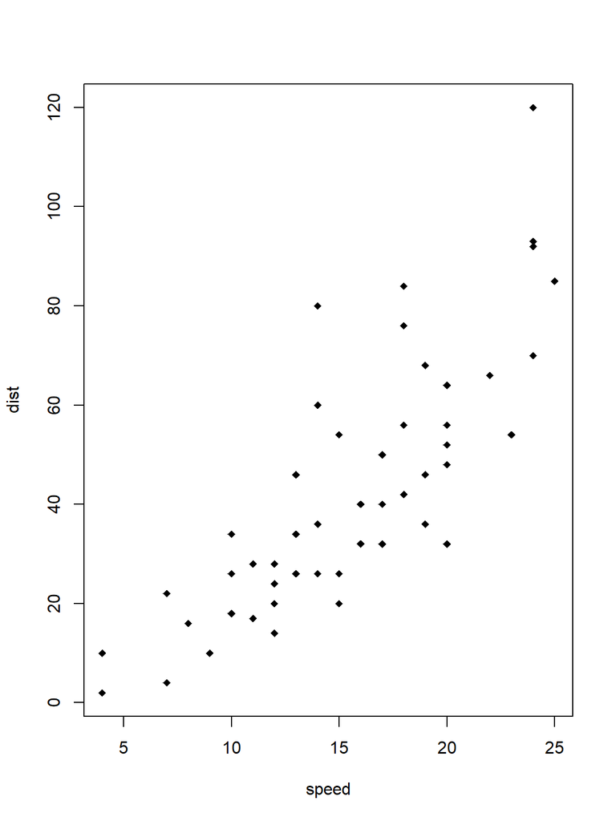

```r
plot(cars, pch = 18)
```

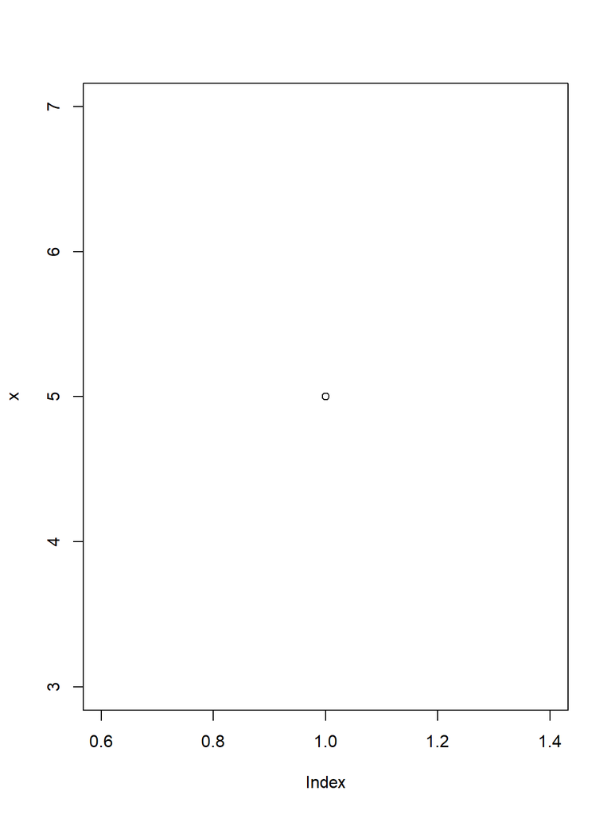

```r
plot(x)
```

# Gráficos Interativos

```r
library(plotly)
library(tidyverse)
library(magrittr)

library(plotly)

accumulate_by <- function(dat, var) {
  var <- lazyeval::f_eval(var, dat)
  lvls <- plotly:::getLevels(var)
  dats <- lapply(seq_along(lvls), function(x) {
    cbind(dat[var %in% lvls[seq(1, x)], ], frame = lvls[[x]])
  })
  dplyr::bind_rows(dats)
}

d <- txhousing %>%
  filter(year > 2005, city %in% c("Abilene", "Bay Area")) %>%
  accumulate_by(~date)

p <- d %>%
  plot_ly(
    x = ~date,
    y = ~median,
    split = ~city,
    frame = ~frame,
    type = 'scatter',
    mode = 'lines',
    line = list(simplyfy = F)
  ) %>%
  layout(
    xaxis = list(
      title = "Date",
      zeroline = F
    ),
    yaxis = list(
      title = "Median",
      zeroline = F
    )
  ) %>%
  animation_opts(
    frame = 100,
    transition = 0,
    redraw = FALSE
  ) %>%
  animation_slider(
    hide = T
    ) %>%
  animation_button(
    x = 1, xanchor = "right", y = 0, yanchor = "bottom"
  )

p
```

[interactive chart not shown]

Website de plots interativos [Plotly](https://plot.ly/r/)

# Documento HTML

- `number_sections: true`: Irá enumerar tudo que começa com #;
- `{.tabset}` ou `{.tabset .tabset-fade .tabset-pills}`: Você pode organizar as sessões usando tabs atribuído aos cabeçalhos. Isso irá causar todos os sub-cabeçalhos.

## Aparência e Estilo

- `theme`: especifica o tema para ser usado para a página. Temas válidos incluem default, cerulean, journal, flatly, darkly, readable, spacelab, united, cosmo, lumen, paper, sandstone, simplex, and yeti. [Bootswatch](https://bootswatch.com/3/) É possível adicionar novos temas instalando alguns pacotes [Galeria de temas](http://www.datadreaming.org/post/r-markdown-theme-gallery/)
- `highlight`: Especifica a sintaxe do estilo destacado. Os estilos suportados são default, tango, pygments, kate, monochrome, espresso, zenburn, haddock, and textmate.

## Opções de figura

Existem várias opções que afetam a saída das figuras nos documentos HTML:  
- `fig_width` and `fig_height` podem ser usados para controlar a largura e comprimento padrões da figura (7x5 é usada como padrão);  
- `fig_caption`: controla se as figuras estão sendo renderizadas com legendas.

Exemplo: `--- title: "Habits" output: html_document: fig_width: 7 fig_height: 6 fig_caption: true ---`

- `df_print: paged`: Imprime as tabelas com paginação nas linhas e colunas
- `code_folding: hide`: Essa opção faz com que o código R seja incluso, mas fica escondido por padrão

# Tabela

## KNITR E KABLEEXTRA

Para criar ótimas tabelas é preciso usar knitr::kable e kableExtra. Os detalhes das configurações estão no link [kableExtra](http://haozhu233.github.io/kableExtra/awesome_table_in_html.html)

```r
library(knitr)
library(kableExtra)
dt <- mtcars[1:5, 1:6]

dt %>%
  kable() %>%
  kable_styling()
```

|  | mpg | cyl | disp | hp | drat | wt |
| --- | --- | --- | --- | --- | --- | --- |
| Mazda RX4 | 21.0 | 6 | 160 | 110 | 3.90 | 2.620 |
| Mazda RX4 Wag | 21.0 | 6 | 160 | 110 | 3.90 | 2.875 |
| Datsun 710 | 22.8 | 4 | 108 | 93 | 3.85 | 2.320 |
| Hornet 4 Drive | 21.4 | 6 | 258 | 110 | 3.08 | 3.215 |
| Hornet Sportabout | 18.7 | 8 | 360 | 175 | 3.15 | 3.440 |

## DT

https://rstudio.github.io/DT/  
# Tipos de arquivos gerados pelo Rmarkdown

- HTML https://bookdown.org/yihui/rmarkdown/
- Notebook
- PDF
- Word
- Pacote R
- Apresentações: [Xaringan](https://slides.yihui.name/xaringan/#1) [Xaringan Bookdown](https://bookdown.org/yihui/rmarkdown/xaringan.html) ;
- Dashboards: [Flexdashboard](https://rmarkdown.rstudio.com/flexdashboard/examples.html) https://rmarkdown.rstudio.com/flexdashboard/ ;
- Folhetos Tufte
- WebSites. [Exemplo/Emily](http://www.emilyzabor.com/) [Tutorial Emily](https://www.emilyzabor.com/tutorials/rmarkdown_websites_tutorial.html);
- Livros [Efficient R programming](https://bookdown.org/csgillespie/efficientR/) ; [Introducing Bookdown](https://www.rstudio.com/resources/webinars/introducing-bookdown/)
- Blogs [Curso-R](https://www.curso-r.com/blog/); https://bookdown.org/yihui/blogdown/
[^1]: Essa é uma nota de rodapé
[^2]: oi